# MA5755_Project: Loan Default Prediction

Group-9

2022-05-17

### Introduction

#### Problem

In this project, we want to know the chance that some customers will default their loan payment and use that as a parameter to decide whether to approve or disapprove the loan. Also, to identify and specifically target the customers segments, those are eligible for loan amount

#### Objective

The goal of this project is to build a model that will classify if a certain customer will default its loan payment or not.

#### Dataset Description

Dream Housing Finance company deals in all home loans. They have presence across all urban, semi urban and rural areas. Customer first apply for home loan after that company validates the customer eligibility for loan. Company wants to automate the loan eligibility process (real time) based on customer detail provided while filling online application form. These details are Gender, Marital Status, Education, Number of Dependents, Income, Loan Amount, Credit History and others. We are using there partial data set available on Kaggle Platform.

### Importing the data set

```r
data <- read.csv('loan_data_set.csv')
```

### Checking for the structure of the data

```r
str(data)
```

```
'data.frame':   614 obs. of  13 variables:
 $ Loan_ID          : chr  "LP001002" "LP001003" "LP001005" "LP001006" ...
 $ Gender           : chr  "Male" "Male" "Male" "Male" ...
 $ Married          : chr  "No" "Yes" "Yes" "Yes" ...
 $ Dependents       : chr  "0" "1" "0" "0" ...
 $ Education        : chr  "Graduate" "Graduate" "Graduate" "Not Graduate" ...
 $ Self_Employed    : chr  "No" "No" "Yes" "No" ...
 $ ApplicantIncome  : int  5849 4583 3000 2583 6000 5417 2333 3036 4006 12841 ...
 $ CoapplicantIncome: num  0 1508 0 2358 0 ...
 $ LoanAmount       : int  NA 128 66 120 141 267 95 158 168 349 ...
 $ Loan_Amount_Term : int  360 360 360 360 360 360 360 360 360 360 ...
 $ Credit_History   : int  1 1 1 1 1 1 1 0 1 1 ...
 $ Property_Area    : chr  "Urban" "Rural" "Urban" "Urban" ...
 $ Loan_Status      : chr  "Y" "N" "Y" "Y" ...
```

The data set consist of 614 observations with 13 variables out which there are 8 character variables, 4 integer variables and 1 numeric variable.

#### Convert all character columns to factor

```r
data <- as.data.frame(unclass(data), stringsAsFactors = TRUE)
str(data)
```

```
'data.frame':   614 obs. of  13 variables:
 $ Loan_ID          : Factor w/ 614 levels "LP001002","LP001003",..: 1 2 3 4 5 6 7 8 9 10 ...
 $ Gender           : Factor w/ 3 levels "","Female","Male": 3 3 3 3 3 3 3 3 3 3 ...
 $ Married          : Factor w/ 3 levels "","No","Yes": 2 3 3 3 2 3 3 3 3 3 ...
 $ Dependents       : Factor w/ 5 levels "","0","1","2",..: 2 3 2 2 2 4 2 5 4 3 ...
 $ Education        : Factor w/ 2 levels "Graduate","Not Graduate": 1 1 1 2 1 1 2 1 1 1 ...
 $ Self_Employed    : Factor w/ 3 levels "","No","Yes": 2 2 3 2 2 3 2 2 2 2 ...
 $ ApplicantIncome  : int  5849 4583 3000 2583 6000 5417 2333 3036 4006 12841 ...
 $ CoapplicantIncome: num  0 1508 0 2358 0 ...
 $ LoanAmount       : int  NA 128 66 120 141 267 95 158 168 349 ...
 $ Loan_Amount_Term : int  360 360 360 360 360 360 360 360 360 360 ...
 $ Credit_History   : int  1 1 1 1 1 1 1 0 1 1 ...
 $ Property_Area    : Factor w/ 3 levels "Rural","Semiurban",..: 3 1 3 3 3 3 3 2 3 2 ...
 $ Loan_Status      : Factor w/ 2 levels "N","Y": 2 1 2 2 2 2 2 1 2 1 ...
```

All the 8 character variables are now converted to categorical variables.

### Extract top 10 observations

```r
head(data, n = 10)
```

|  | Loan_ID | Gender | Married | Dependents | Education | Self_Employed | ApplicantIncome | CoapplicantIncome | LoanAmount | Loan_Amount_Term | Credit_History | Property_Area | Loan_Status |
| --- | --- | --- | --- | --- | --- | --- | --- | --- | --- | --- | --- | --- | --- |
| 1 | LP001002 | Male | No | 0 | Graduate | No | 5849 | 0 | NA | 360 | 1 | Urban | Y |
| 2 | LP001003 | Male | Yes | 1 | Graduate | No | 4583 | 1508 | 128 | 360 | 1 | Rural | N |
| 3 | LP001005 | Male | Yes | 0 | Graduate | Yes | 3000 | 0 | 66 | 360 | 1 | Urban | Y |
| 4 | LP001006 | Male | Yes | 0 | Not Graduate | No | 2583 | 2358 | 120 | 360 | 1 | Urban | Y |
| 5 | LP001008 | Male | No | 0 | Graduate | No | 6000 | 0 | 141 | 360 | 1 | Urban | Y |
| 6 | LP001011 | Male | Yes | 2 | Graduate | Yes | 5417 | 4196 | 267 | 360 | 1 | Urban | Y |
| 7 | LP001013 | Male | Yes | 0 | Not Graduate | No | 2333 | 1516 | 95 | 360 | 1 | Urban | Y |
| 8 | LP001014 | Male | Yes | 3+ | Graduate | No | 3036 | 2504 | 158 | 360 | 0 | Semiurban | N |
| 9 | LP001018 | Male | Yes | 2 | Graduate | No | 4006 | 1526 | 168 | 360 | 1 | Urban | Y |
| 10 | LP001020 | Male | Yes | 1 | Graduate | No | 12841 | 10968 | 349 | 360 | 1 | Semiurban | N |

### Data Pre-processing

#### Checking for the structure and other possible incompleteness

```r
summary(data)
```

```
     Loan_ID       Gender    Married   Dependents        Education   Self_Employed ApplicantIncome
 LP001002:  1         : 13      :  3     : 15     Graduate    :480      : 32       Min.   :  150
 LP001003:  1   Female:112   No :213   0 :345     Not Graduate:134   No :500       1st Qu.: 2878
 LP001005:  1   Male  :489   Yes:398   1 :102                        Yes: 82       Median : 3812
 LP001006:  1                          2 :101                                      Mean   : 5403
 LP001008:  1                          3+: 51                                      3rd Qu.: 5795
 LP001011:  1                                                                      Max.   :81000
 (Other) :608
 CoapplicantIncome   LoanAmount    Loan_Amount_Term Credit_History     Property_Area Loan_Status
 Min.   :    0     Min.   :  9.0   Min.   : 12      Min.   :0.0000   Rural    :179   N:192
 1st Qu.:    0     1st Qu.:100.0   1st Qu.:360      1st Qu.:1.0000   Semiurban:233   Y:422
 Median : 1188     Median :128.0   Median :360      Median :1.0000   Urban    :202
 Mean   : 1621     Mean   :146.4   Mean   :342      Mean   :0.8422
 3rd Qu.: 2297     3rd Qu.:168.0   3rd Qu.:360      3rd Qu.:1.0000
 Max.   :41667     Max.   :700.0   Max.   :480      Max.   :1.0000
                   NA's   :22      NA's   :14       NA's   :50
```

The summary reveals that there are some blank spaces. For instance: Gender has 13 blank spaces, Married has 3, Dependents has 15, Self_Employed has 32, LoanAmount has 22, Loan_Amount_Term has 14 & Credit_History has 50. Which sums to 149.

More so, the summary statistics gives us a view of the skewness of the numeric variables;i.e how close or far away the mean is from the median(middle) mainly for numeric data.

#### Replacing blank spaces with NAs

```r
data[data == ""] <- NA
```

We have been able to replace the blank spaces with NA’s which will now be captured by R as a missing number.

#### Checking for missing data

```r
sum(is.na(data))
```

```
[1] 149
```

This shows that there are 149 missing values in the data set

#### Summary of the data

```r
summary(data)
```

```
     Loan_ID       Gender    Married    Dependents        Education   Self_Employed ApplicantIncome
 LP001002:  1         :  0       :  0       :  0   Graduate    :480       :  0      Min.   :  150
 LP001003:  1   Female:112   No  :213   0   :345   Not Graduate:134   No  :500      1st Qu.: 2878
 LP001005:  1   Male  :489   Yes :398   1   :102                      Yes : 82      Median : 3812
 LP001006:  1   NA's  : 13   NA's:  3   2   :101                      NA's: 32      Mean   : 5403
 LP001008:  1                           3+  : 51                                    3rd Qu.: 5795
 LP001011:  1                           NA's: 15                                    Max.   :81000
 (Other) :608
 CoapplicantIncome   LoanAmount    Loan_Amount_Term Credit_History     Property_Area Loan_Status
 Min.   :    0     Min.   :  9.0   Min.   : 12      Min.   :0.0000   Rural    :179   N:192
 1st Qu.:    0     1st Qu.:100.0   1st Qu.:360      1st Qu.:1.0000   Semiurban:233   Y:422
 Median : 1188     Median :128.0   Median :360      Median :1.0000   Urban    :202
 Mean   : 1621     Mean   :146.4   Mean   :342      Mean   :0.8422
 3rd Qu.: 2297     3rd Qu.:168.0   3rd Qu.:360      3rd Qu.:1.0000
 Max.   :41667     Max.   :700.0   Max.   :480      Max.   :1.0000
                   NA's   :22      NA's   :14       NA's   :50
```

The summary statistic has now clearly shown the missing numbers and variables that has the missing values. For instance, Dependents now has 15 NA’s as compared to 15 blank spaces it has earlier.

#### Handling missing number using KNN Imputation method

```r
library(VIM)
#Picking the columns with missing number
data1 <- kNN(data,variable = c("Gender","Married","Dependents","Self_Employed","LoanAmount","Loan_Amount_Term",
                               "Credit_History"), k = 7)
summary(data1)
```

```
     Loan_ID       Gender    Married   Dependents        Education   Self_Employed ApplicantIncome
 LP001002:  1         :  0      :  0     :  0     Graduate    :480      :  0       Min.   :  150
 LP001003:  1   Female:113   No :213   0 :353     Not Graduate:134   No :532       1st Qu.: 2878
 LP001005:  1   Male  :501   Yes:401   1 :104                        Yes: 82       Median : 3812
 LP001006:  1                          2 :106                                      Mean   : 5403
 LP001008:  1                          3+: 51                                      3rd Qu.: 5795
 LP001011:  1                                                                      Max.   :81000
 (Other) :608
 CoapplicantIncome   LoanAmount    Loan_Amount_Term Credit_History     Property_Area Loan_Status Gender_imp
 Min.   :    0     Min.   :  9.0   Min.   : 12.0    Min.   :0.0000   Rural    :179   N:192       Mode :logical
 1st Qu.:    0     1st Qu.:100.0   1st Qu.:360.0    1st Qu.:1.0000   Semiurban:233   Y:422       FALSE:601
 Median : 1188     Median :127.0   Median :360.0    Median :1.0000   Urban    :202               TRUE :13
 Mean   : 1621     Mean   :145.4   Mean   :342.4    Mean   :0.8453
 3rd Qu.: 2297     3rd Qu.:165.0   3rd Qu.:360.0    3rd Qu.:1.0000
 Max.   :41667     Max.   :700.0   Max.   :480.0    Max.   :1.0000

 Married_imp     Dependents_imp  Self_Employed_imp LoanAmount_imp  Loan_Amount_Term_imp Credit_History_imp
 Mode :logical   Mode :logical   Mode :logical     Mode :logical   Mode :logical        Mode :logical
 FALSE:611       FALSE:599       FALSE:582         FALSE:592       FALSE:600            FALSE:564
 TRUE :3         TRUE :15        TRUE :32          TRUE :22        TRUE :14             TRUE :50
```

#### Subsetting the data

```r
data1 <- subset(data1, select = Loan_ID:Loan_Status)
sum(is.na(data1))
```

```
[1] 0
```

The data set now has 0 missing values.

#### Summary of the data

```r
library(psych)
describe(data1)
```

|  | vars | n | mean | sd | median | trimmed | mad | min | max | range | skew | kurtosis | se |
| --- | --- | --- | --- | --- | --- | --- | --- | --- | --- | --- | --- | --- | --- |
| Loan_ID* | 1 | 614 | 307.50 | 177.39 | 307.5 | 307.50 | 227.58 | 1 | 614 | 613 | 0.00 | -1.21 | 7.16 |
| Gender* | 2 | 614 | 2.82 | 0.39 | 3.0 | 2.89 | 0.00 | 2 | 3 | 1 | -1.63 | 0.65 | 0.02 |
| Married* | 3 | 614 | 2.65 | 0.48 | 3.0 | 2.69 | 0.00 | 2 | 3 | 1 | -0.64 | -1.59 | 0.02 |
| Dependents* | 4 | 614 | 2.76 | 1.01 | 2.0 | 2.60 | 0.00 | 2 | 5 | 3 | 0.96 | -0.46 | 0.04 |
| Education* | 5 | 614 | 1.22 | 0.41 | 1.0 | 1.15 | 0.00 | 1 | 2 | 1 | 1.36 | -0.15 | 0.02 |
| Self_Employed* | 6 | 614 | 2.13 | 0.34 | 2.0 | 2.04 | 0.00 | 2 | 3 | 1 | 2.15 | 2.62 | 0.01 |
| ApplicantIncome | 7 | 614 | 5403.46 | 6109.04 | 3812.5 | 4292.06 | 1822.86 | 150 | 81000 | 80850 | 6.51 | 59.83 | 246.54 |
| CoapplicantIncome | 8 | 614 | 1621.25 | 2926.25 | 1188.5 | 1154.85 | 1762.07 | 0 | 41667 | 41667 | 7.45 | 83.97 | 118.09 |
| LoanAmount | 9 | 614 | 145.44 | 84.31 | 127.0 | 132.36 | 45.96 | 9 | 700 | 691 | 2.72 | 10.70 | 3.40 |
| Loan_Amount_Term | 10 | 614 | 342.41 | 64.43 | 360.0 | 358.54 | 0.00 | 12 | 480 | 468 | -2.39 | 6.83 | 2.60 |

[output cut: 3 more lines]

Describes gives us a broad range of summary statistics.

### Exploratory Data Analysis

### Correlation Matrix

#### Checking for correlation and multicollinearity between the variables

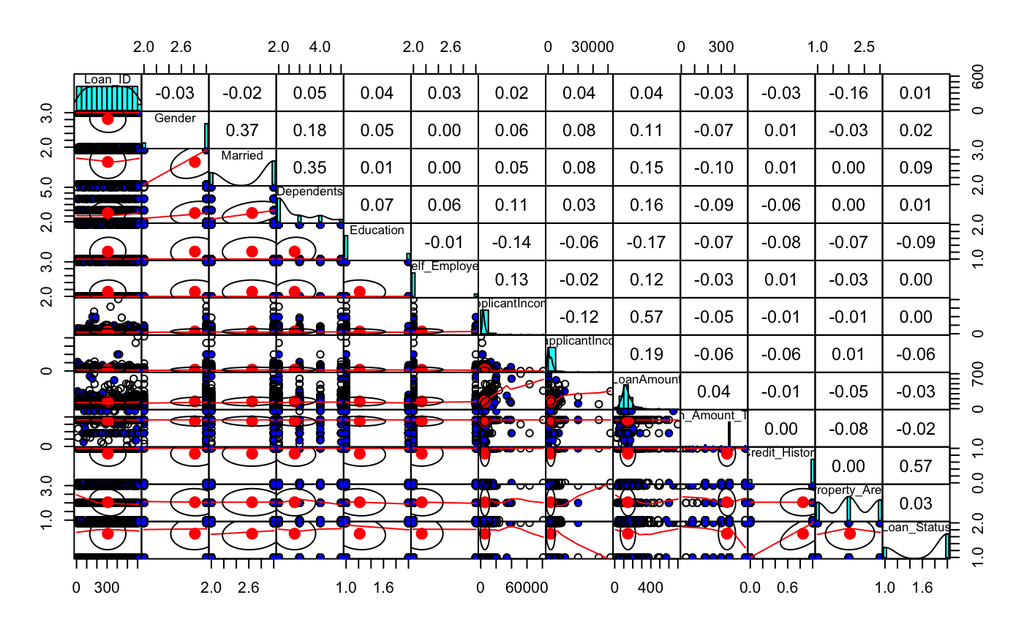

```r
library(psych)
pairs.panels (data1, gap = 0, bg = c("red","green","blue"[data1$Loan_Status]), pch = 21)
```

### Checking for outlier

#### using Box Plot

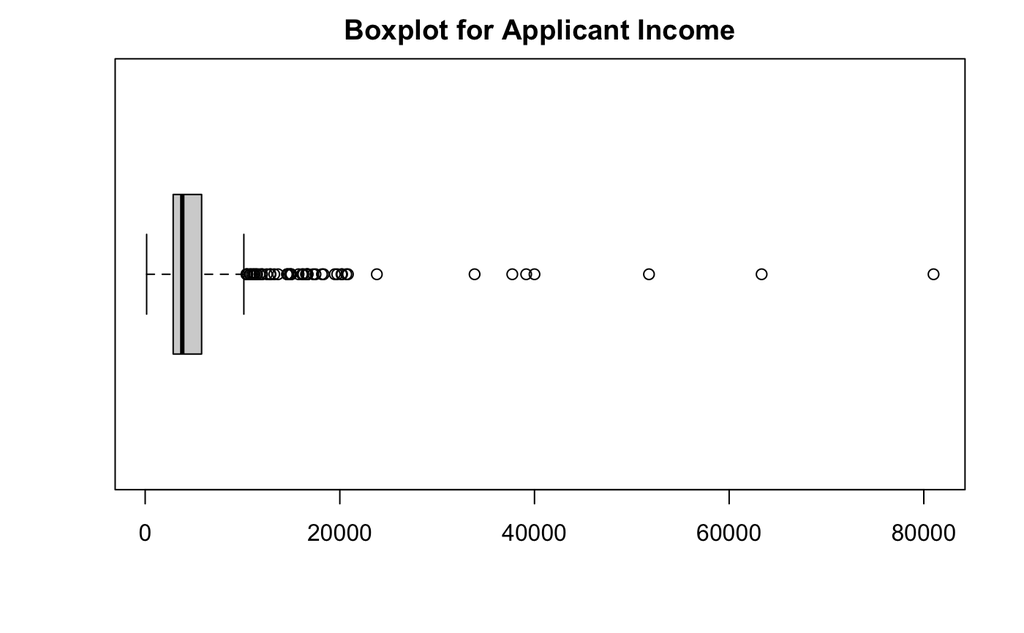

```r
boxplot(data1$ApplicantIncome, horizontal = TRUE, main = "Boxplot for Applicant Income")
```

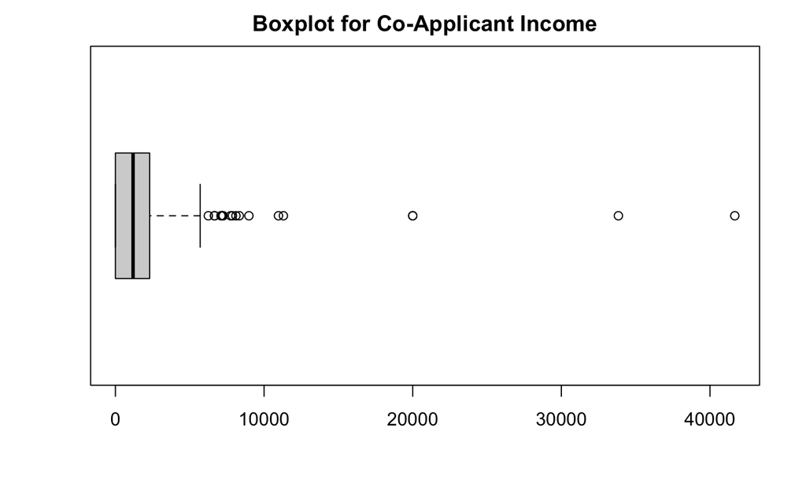

```r
boxplot(data1$CoapplicantIncome, horizontal = TRUE, main = "Boxplot for Co-Applicant Income")
```

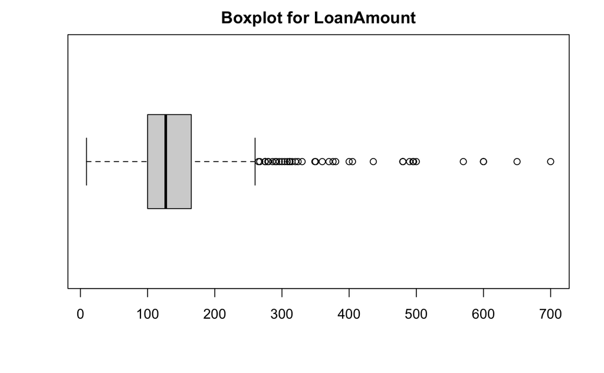

```r
boxplot(data1$LoanAmount, horizontal = TRUE, main = "Boxplot for LoanAmount")
```

### Outlier Treatment for ApplicantIncome,CoapplicantIncome and LoanAmount

#### ApplicantIncome

```r
bench <- 5795 + 1.5*IQR(data1$ApplicantIncome) #Q3 + 1.5*IQR(data)
bench
```

```
[1] 10171.25
```

```r
#Winsorizing method of treating outlier
data1$ApplicantIncome[data1$ApplicantIncome > bench]
```

```
 [1] 12841 12500 11500 10750 13650 11417 14583 10408 23803 10513 20166 14999 11757 14866 39999 51763 33846 39147
[19] 12000 11000 16250 14683 11146 14583 20667 20233 15000 63337 19730 15759 81000 14880 12876 10416 37719 16692
[37] 16525 16667 10833 18333 17263 20833 13262 17500 11250 18165 19484 16666 16120 12000
```

```r
data1$ApplicantIncome[data1$ApplicantIncome > bench] <- bench
summary(data1$ApplicantIncome)
```

```
   Min. 1st Qu.  Median    Mean 3rd Qu.    Max.
    150    2878    3812    4617    5795   10171
```

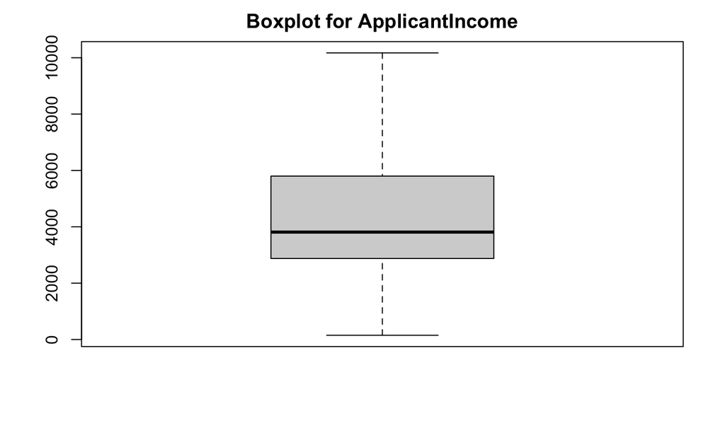

```r
boxplot(data1$ApplicantIncome, main = "Boxplot for ApplicantIncome")
```

```r
length(data1$ApplicantIncome)
```

```
[1] 614
```

#### CoapplicantIncome

```r
bench <- 2297 + 1.5*IQR(data1$CoapplicantIncome) #Q3 + 1.5*IQR(data)
bench
```

```
[1] 5742.875
```

```r
#Winsorizing method of treating outlier
data1$CoapplicantIncome[data1$CoapplicantIncome > bench]
```

```
 [1] 10968  8106  7210  8980  7750 11300  7250  7101  6250  7873 20000 20000  8333  6667  6666  7166 33837 41667
```

```r
data1$CoapplicantIncome[data1$CoapplicantIncome > bench] <- bench
summary(data1$CoapplicantIncome)
```

```
   Min. 1st Qu.  Median    Mean 3rd Qu.    Max.
      0       0    1188    1420    2297    5743
```

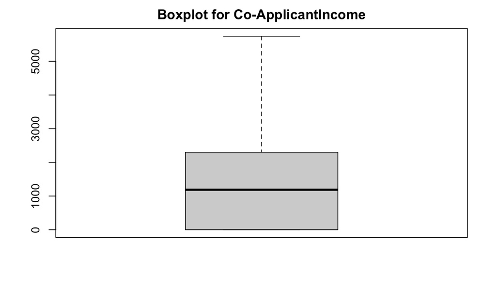

```r
boxplot(data1$CoapplicantIncome, main = "Boxplot for Co-ApplicantIncome")
```

```r
length(data1$CoapplicantIncome)
```

```
[1] 614
```

#### LoanAmount

```r
bench <- 165 + 1.5*IQR(data1$LoanAmount) #Q3 + 1.5*IQR(data)
bench
```

```
[1] 262.5
```

```r
#Winsorizing method of treating outlier
data1$LoanAmount[data1$LoanAmount > bench]
```

```
 [1] 267 349 315 320 286 312 265 370 650 290 600 275 700 495 280 279 304 330 436 480 300 376 490 308 570 380 296
[28] 275 360 405 500 480 311 480 400 324 600 275 292 350 496
```

```r
data1$LoanAmount[data1$LoanAmount > bench] <- bench
summary(data1$LoanAmount)
```

```
   Min. 1st Qu.  Median    Mean 3rd Qu.    Max.
    9.0   100.0   127.0   137.1   165.0   262.5
```

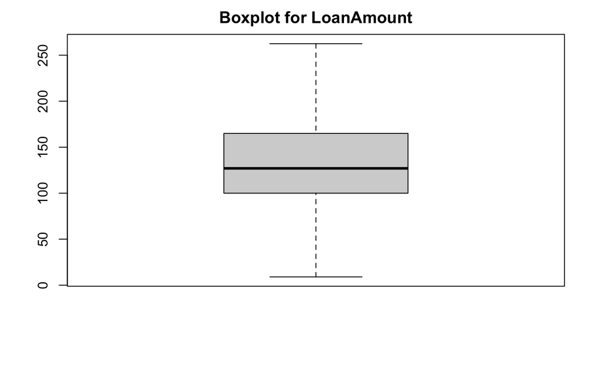

```r
boxplot(data1$LoanAmount, main = "Boxplot for LoanAmount")
```

```r
length(data1$LoanAmount)
```

```
[1] 614
```

```r
prop.table(table(data1$Loan_Status))
```

```
        N         Y
0.3127036 0.6872964
```

```r
table(data1$Loan_Status)
```

```
  N   Y
192 422
```

Class imbalance is a situation, mostly in classification model building; where the total number of positive class of a data set is extremely lower than the total number of the negative class.

In the data set, we have 68.7% of the response variable as YES and 31.3% as NO.Hence, we can conclude that there is no class imbalance in this data set.

### Train & Test set

```r
set.seed(222)
split = sample(2,nrow(data1),prob = c(0.75, 0.25),replace = TRUE)
train_set = data1[split == 1,]
test_set = data1[split == 2,]
```

It is the usual practice in Machine Learning field to divide the data set into train and test set. The model will be built on the train set and the performance of the model will be tested on the test.

### Logistic Regression

Logistic regression uses sigmoid function to classify variables into classes and its basically applicable to classification problems. Other applicable models for classification problems are Decision Tree, Random Forest, Naive Bayes, Neural Network and so on.

For the purpose of this project we will be using Decision Tree and Random Forest along with Logistic Regression.

```r
# Fitting Logistic Regression to the Training set
logistics_classifier = glm(formula = Loan_Status ~ ., family = binomial, data = train_set[,-c(1)])

summary(logistics_classifier)
```

```
Call:
glm(formula = Loan_Status ~ ., family = binomial, data = train_set[,
    -c(1)])

Deviance Residuals:
    Min       1Q   Median       3Q      Max
-2.5113  -0.2663   0.4840   0.6735   2.9870

Coefficients:
                         Estimate Std. Error z value Pr(>|z|)
(Intercept)            -3.263e+00  1.103e+00  -2.958  0.00310 **
GenderMale             -4.743e-01  3.628e-01  -1.307  0.19119
MarriedYes              8.746e-01  3.039e-01   2.878  0.00401 **
Dependents1            -6.002e-01  3.488e-01  -1.721  0.08529 .
Dependents2             3.587e-01  4.224e-01   0.849  0.39573
Dependents3+            1.747e-01  5.210e-01   0.335  0.73739
EducationNot Graduate  -3.602e-01  3.124e-01  -1.153  0.24887
Self_EmployedYes        3.116e-01  4.024e-01   0.774  0.43869
ApplicantIncome         3.763e-05  7.908e-05   0.476  0.63414
CoapplicantIncome       1.344e-04  1.020e-04   1.318  0.18747
LoanAmount             -5.838e-03  3.418e-03  -1.708  0.08760 .
Loan_Amount_Term       -3.832e-04  2.173e-03  -0.176  0.86002
Credit_History          4.773e+00  6.185e-01   7.717 1.19e-14 ***
Property_AreaSemiurban  8.257e-01  3.198e-01   2.582  0.00981 **
Property_AreaUrban      3.806e-01  3.156e-01   1.206  0.22784
---
Signif. codes:  0 ‘***’ 0.001 ‘**’ 0.01 ‘*’ 0.05 ‘.’ 0.1 ‘ ’ 1

(Dispersion parameter for binomial family taken to be 1)

    Null deviance: 591.70  on 471  degrees of freedom
Residual deviance: 396.18  on 457  degrees of freedom
AIC: 426.18

Number of Fisher Scoring iterations: 5
```

Based on the output of the Logistic regression,only 3 variables are significant while other are insignificant.

Credit_History is an important factor in deciding whether a client will default or not and this was clearly in tune with the outcome of the model. Whether the customer is married or not is also a significant factor, as far as this data set is concerned.

#### Prediction using Logistics Regression

```r
# Predicting the Test set results
prob_pred = predict(logistics_classifier, type = 'response', newdata = test_set)
y_pred = ifelse(prob_pred > 0.5, 1, 0)
```

#### Estimating the performance of the model

```r
# Confusion Matrix
cm = table(ActualValue=test_set$Loan_Status, PredictedValue=prob_pred > 0.5)
cm
```

```
           PredictedValue
ActualValue FALSE TRUE
          N    17   24
          Y     4   97
```

```r
#Estimating the percentage of performance
sum(diag(cm))/sum(cm)
```

```
[1] 0.8028169
```

Logistics Regression was able to give us an accuracy of 80.28%, which means that we can expect our model to classify correct about 8 observations in every 10.

### Decision Tree

```r
library(party)
Tree_Classifer = ctree(Loan_Status ~ ., data = train_set[,-c(1)])
Tree_Classifer
```

```
     Conditional inference tree with 3 terminal nodes

Response:  Loan_Status
Inputs:  Gender, Married, Dependents, Education, Self_Employed, ApplicantIncome, CoapplicantIncome, LoanAmount, Loan_Amount_Term, Credit_History, Property_Area
Number of observations:  472

1) Credit_History <= 0; criterion = 1, statistic = 164.631
  2)*  weights = 74
1) Credit_History > 0
  3) Married == {Yes}; criterion = 0.975, statistic = 9.784
    4)*  weights = 266
  3) Married == {No}
    5)*  weights = 132
```

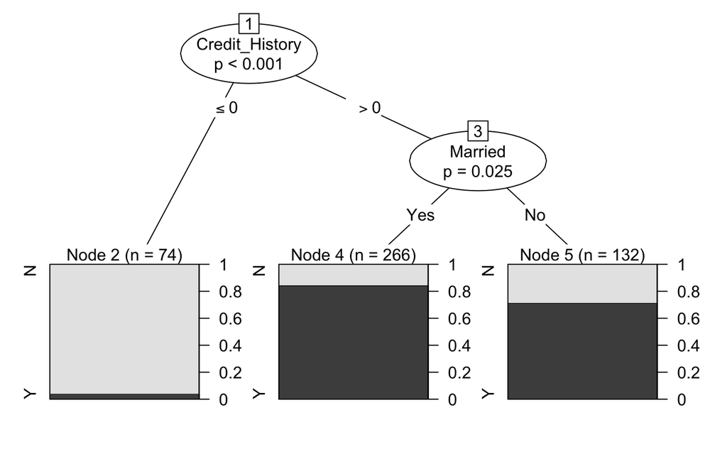

```r
plot(Tree_Classifer)
```

The decision tree model also corroborated the position of the logistic regression by making credit_history as the most important variable for consideration when deciding if a customer is going to default or not.

#### Prediction using Decision Tree

```r
# Predicting the Test set results
pred = predict(Tree_Classifer, newdata = test_set)
```

#### Estimating the performance of the model

```r
# Confusion Matrix
cm = table(ActualValue=test_set$Loan_Status, PredictedValue=pred)
cm
```

```
           PredictedValue
ActualValue  N  Y
          N 17 24
          Y  4 97
```

```r
#Estimating the percentage of performance
sum(diag(cm))/sum(cm)
```

```
[1] 0.8028169
```

The level of accuracy achieved by the Decision Tree model is similar to that of logistics regression at 80.28%

### Random Forest

Random Forest is ensemble method in that it averages the performance of 500 Decision Trees to arrive at its output where Decision Tree employs only just one Tree.The 500 tree were chosen at random. Its the reason the model is regarded as Random Forest.

```r
library(randomForest)
set.seed(153)
rf_classifier <- randomForest(Loan_Status ~ ., data = train_set[,-c(1)])

str(rf_classifier)
```

[output not shown]

[output cut: 19 more lines]

[output not shown]

```r
attributes(rf_classifier)
```

```
$names
 [1] "call"            "type"            "predicted"       "err.rate"        "confusion"       "votes"
 [7] "oob.times"       "classes"         "importance"      "importanceSD"    "localImportance" "proximity"
[13] "ntree"           "mtry"            "forest"          "y"               "test"            "inbag"
[19] "terms"

$class
[1] "randomForest.formula" "randomForest"
```

#### Prediction using Random Forest

```r
# Predicting the Test set results
rf_pred = predict(rf_classifier,newdata = test_set)
```

#### Estimating the performance of the model

```r
# Confusion Matrix
cm = table(ActualValue=test_set$Loan_Status, PredictedValue=rf_pred)
cm
```

```
           PredictedValue
ActualValue  N  Y
          N 19 22
          Y  6 95
```

```r
#Estimating the percentage of performance
sum(diag(cm))/sum(cm)
```

```
[1] 0.8028169
```

The level of accuracy achieved by the Random Forest model is also 80.28%

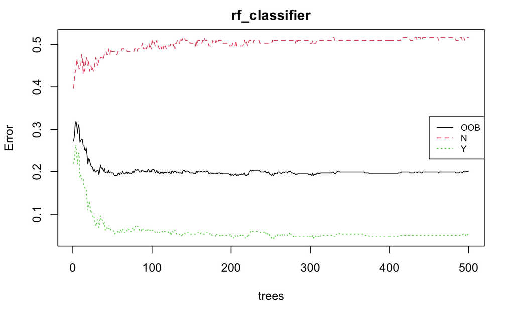

```r
plot(rf_classifier)
legend("right", cex = 0.75, legend = {colnames(rf_classifier$err.rate)}, lty=c(1,2,3), col=c(1,2,3), horiz=F)
```

#### Determining the most important variable in the forest

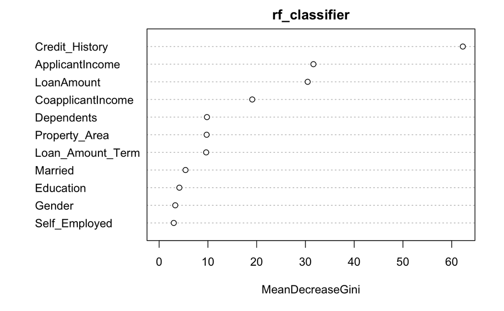

```r
varImpPlot(rf_classifier)
```

```r
importance(rf_classifier)
```

```
                  MeanDecreaseGini
Gender                    3.303429
Married                   5.407847
Dependents                9.802210
Education                 4.148128
Self_Employed             2.998537
ApplicantIncome          31.639272
CoapplicantIncome        19.093157
LoanAmount               30.461449
Loan_Amount_Term          9.641188
Credit_History           62.282279
Property_Area             9.738555
```

The Random Forest model also ranked Credit_History as the most important variable just the other 2 previous models. While Random Forest agree that ApplicantIncome is another important variable; Logistics regression chose Married.

### Conclusion

Based on the performance of Logistics Regression, Decision Tree and Random Forest models; we can conclude that if adequate pre-processing methods were carefully observed; these models can perform extremely well on classification problem.